# Additional table manipulations

Author

Affiliation

dr.sc. Paula Breyer

Bioinformatics group

## Read tabular data

### Path

**Important**

An **absolute path** always contains the root element and the complete directory list required to locate the file.

- `D:/User/MyFolder/Algorithms_and_programming/Homework/`

A **relative path** needs to be combined with another path in order to access a file.

- `../Algorithms_and_programming/Homework/`

We save the path to a CSV file from the web into a variable called `my_file`. This file will be used for demonstrations throughout the lecture.

```r
my_file <- "https://raw.githubusercontent.com/bot13956/datasets/master/introduction_to_physics_grades.csv"
```

### CSV and TSV

Tab Separated Values (TSV)and Comma Separated Values (CSV). A .tsv file will have tab separated values whereas .csv file has comma separated fields.

[figure not shown]

**Note**

Each function for correctly importing tables contains important arguments such as,

- **`header`** - If TRUE then any empty column names are given a name where first data line is a character (non-empty)
- **`sep`** - The separator between columns. Most commonly used are “;”, “,”;“..
- **`skip`** - number of lines to skip before reading starts (default 0). In `fread()` it can also be a string: reading starts at the first line containing that string
- **`fill`** - If TRUE then in case the rows have unequal length, blank fields are implicitly added
- **`dec`** - the character used in the file for decimal points
- **`col_names`** - assign new column names (string)

and many others depending on the used function.

#### read.csv or read.tsv

Reads a file in table format and creates a data frame from it, with cases corresponding to lines and variables to fields in the file.

```r
read.csv( my_file )
```

| Count | Score | Grade |
| --- | --- | --- |
| 1 | 75.0 | C |
| 2 | 5.0 | F |
| 3 | 20.0 | F |
| 4 | 87.5 | B |
| 5 | 100.0 | A |
| 6 | 97.5 | A |
| 7 | 95.0 | A |
| 8 | 30.0 | F |
| 9 | 65.0 | D |
| 10 | 37.5 | F |

[output cut: 789 more lines]

#### read.table

Reads a file in table format and creates a data frame from it, with cases corresponding to lines and variables to fields in the file.

```r
read.table( my_file )
```

| V1 |
| --- |
| Count,Score,Grade |
| 1,75.0,C |
| 2,5.0,F |
| 3,20.0,F |
| 4,87.5,B |
| 5,100.0,A |
| 6,97.5,A |
| 7,95.0,A |
| 8,30.0,F |
| 9,65.0,D |

[output cut: 790 more lines]

#### fread

Similar to read.table but faster and more convenient. All controls such as sep, colClasses and nrows are automatically detected.

```r
fread( my_file )
```

| Count | Score | Grade |
| --- | --- | --- |
| 1 | 75.0 | C |
| 2 | 5.0 | F |
| 3 | 20.0 | F |
| 4 | 87.5 | B |
| 5 | 100.0 | A |
| 6 | 97.5 | A |
| 7 | 95.0 | A |
| 8 | 30.0 | F |
| 9 | 65.0 | D |
| 10 | 37.5 | F |

[output cut: 789 more lines]

## Read non-tabular data

Import data one line at the time

#### readLines

```r
# Apply readLines function to txt file
readLines(my_file) %>%
  head()
```

```
[1] "Count,Score,Grade" "1,75.0,C"          "2,5.0,F"
[4] "3,20.0,F"          "4,87.5,B"          "5,100.0,A"
```

#### read_lines from package *readr*

```r
readr::read_lines(my_file) %>%
  head()
```

```
[1] "Count,Score,Grade" "1,75.0,C"          "2,5.0,F"
[4] "3,20.0,F"          "4,87.5,B"          "5,100.0,A"
```

### Reading tabular data as a list or a vector

`scan()` function can also work when handling data that is stored in simple delimited text files. Unlike the `read.table()` function, the `scan()` function returns a list or a vector, not a dataframe.

- **`what`** the type of what gives the type of data to be read. (Here ‘type’ is used in the sense of typeof.) The supported types are logical, integer, numeric, complex, character, raw and list

```r
scan(my_file, sep=",", what = "character") %>% head
```

```
[1] "Count" "Score" "Grade" "1"     "75.0"  "C"
```

```r
scan(my_file,sep=",",  what=list("", "", ""), skip = 1) %>%
  lapply(., function(x) x[1:8])
```

```
[[1]]
[1] "1" "2" "3" "4" "5" "6" "7" "8"

[[2]]
[1] "75.0"  "5.0"   "20.0"  "87.5"  "100.0" "97.5"  "95.0"  "30.0"

[[3]]
[1] "C" "F" "F" "B" "A" "A" "A" "F"
```

`what` takes *example values*, not type names. Writing the type names as strings reads every column as character:

```r
# Wrong: "integer", "numeric" are just strings -> all columns are character
scan(my_file, sep = ",", what = list("integer", "numeric", "character"), skip = 1) %>%
  lapply(., function(x) x[1:8])
```

```
[[1]]
[1] "1" "2" "3" "4" "5" "6" "7" "8"

[[2]]
[1] "75.0"  "5.0"   "20.0"  "87.5"  "100.0" "97.5"  "95.0"  "30.0"

[[3]]
[1] "C" "F" "F" "B" "A" "A" "A" "F"
```

```r
# Right: empty vectors of the wanted type -> integer, numeric, character
scan(my_file, sep = ",", what = list(integer(), numeric(), character()), skip = 1) %>%
  lapply(., function(x) x[1:8])
```

```
[[1]]
[1] 1 2 3 4 5 6 7 8

[[2]]
[1]  75.0   5.0  20.0  87.5 100.0  97.5  95.0  30.0

[[3]]
[1] "C" "F" "F" "B" "A" "A" "A" "F"
```

**Tip**

Factors are not supported by `scan()`; convert afterwards with `factor()`.

## Saving data

**Note**

Important argumnts, my vary depending on the used function

- **`sep`** - The separator between columns (“,”, “;”)
- **`append`** - If TRUE, the file is opened in append mode and column names (header row) are not written. If FALSE, it will overwrite the existing file
- **`quote`** - factor fields and column names will only be surrounded by double quotes
- **`col.names`** or **`row.names`** - T or F

Examples of how to save data

```r
write.table(dt,"PATH/TO/FILE.csv", row.names = FALSE)
write.csv(dt,"PATH/TO/FILE.csv", row.names = FALSE)
fwrite(dt, "PATH/TO/FILE.csv")
```

**Tip**

The `fwrite()` function from the `data.table` package is a fast and efficient way to write data tables to disk.

### R data format

#### Saving a single R object

You can save **one R object** (e.g., a data frame, vector, or model) to a file in **RDS format** using `saveRDS()`.

- **`saveRDS(object, file)`**: writes the object to disk.
- **`readRDS(file)`**: loads the object back into R.
- You can assign the loaded object to **any name** you like (the original object name is not preserved).

```r
# Save a single object to a file
saveRDS(my_table, "my_data.rds")

# Restore it under a different name
my_old_table <- readRDS("my_data.rds")
```

#### Saving multiple R objects (`.RData` / `.rda`)

The `save()` function can store **one or more R objects** together in a single file.  
These files are usually saved with the extension **`.RData`** or **`.rda`**.

- **`save(object1, object2, ..., file = "name.RData")`** → saves the specified objects.
- **`load("name.RData")`** → restores all saved objects into the current workspace with their original names.

```r
# Save multiple objects
save(my_table1, my_table2, file = "data.RData")
# To load the data again
load("data.RData")
```

#### Saving your entire workspace in a specified file

If you want to save **everything currently in your R session** (all variables, data frames, models, functions, etc.), you can use `save.image()`.  
This is essentially a shortcut for saving the entire global environment into a single file, usually with the extension `.RData`.

- **`save.image(file = "my_workspace.RData")`** → saves the entire workspace.
- **`load("my_workspace.RData")`** → restores the full workspace later.

```r
# Save everything from the current R session
save.image(file = "my_work_space.RData")
# load back the workspace
load("my_work_space.RData")
```

**Tip**

While `save.image()` is convenient, it’s not always the best choice:

- It can save **unnecessary objects**, making files very large.
- It may hide **dependencies** (you won’t remember later which objects were actually needed).
- For **reproducibility**, it’s usually better to save only the objects you need with `save()` or `saveRDS()` and rebuild the rest from your script.

**Rule of thumb:**  
Use `save.image()` for quick backups or temporary sessions, but prefer `save()` / `saveRDS()` for clean, shareable projects.

## Excel

### Package: `**readxl**`

The **readxl** package is the most common way to import Excel files in R.  
It has no external dependencies (unlike older packages such as `xlsx` or `XLConnect`) and works on all platforms.

- Supports both `.xls` (Excel 97–2003) and `.xlsx` (Excel 2007+) formats.
- Returns a **tibble** .
- Does **not** require Excel or Java to be installed on your computer.
- Provides fast, read-only access (you cannot write Excel files with `readxl`; for that, use `openxlsx` or `writexl`).

#### Difference between `read_excel`, `read_xls`, and `read_xlsx`

All three functions come from the **readxl** package.

| Function | Supported format(s) | Notes |
| --- | --- | --- |
| `read_excel()` | Both `.xls` and `.xlsx` | Generic function, automatically detects file type. Recommended in most cases. |
| `read_xls()` | Only `.xls` | Wrapper specialized for old Excel files (97–2003). |
| `read_xlsx()` | Only `.xlsx` | Wrapper specialized for modern Excel files (2007+). |

**Tip**

In most cases, just use `read_excel()` — it works for both formats and is the most flexible.

#### Example of manipulation with Excel files

```r
# Read the first sheet by index
read_excel("PATH/TO/EXCEL.xlsx", sheet = 1)

# Read a sheet by name ("ATM" in this case)
read_excel("PATH/TO/EXCEL.xlsx", sheet = "ATM")

# Save the first table into a new Excel file, sheet named "My_sheet"
write.xlsx(my_table,
           file = "PATH/TO/My_EXCEL.xlsx",
           sheetName = "My_sheet",
           col.names = TRUE,
           row.names = TRUE,
           append = FALSE)

# Save a second table into the same file, sheet named "sheet2"
write.xlsx(my_table2,
           file = "PATH/TO/My_EXCEL.xlsx",
           sheetName = "sheet2",
           append = TRUE,
           row.names = FALSE)
```

## Multiple files

**Important**

How to import multiple files at once?

Using **`list.files`** function which has the following important arguments:

- **`path`** - ptah to your folder containing multiple files and subfolders
- **`pattern`** - regular expression
- **`full.names`** - If TRUE, the directory path is prepended to the file names to give a relative file path.

#### Example of importing multiple files

What are the data structures of **temp** and **myfiles** variables?

```r
temp <- list.files(path = "test_data/",
                   pattern="*.csv",
                   full.names = TRUE)
myfiles <- lapply(temp, fread)

temp
```

```
[1] "test_data//breast.csv"   "test_data//colon.csv"
[3] "test_data//lung.csv"     "test_data//prostate.csv"
```

```r
myfiles %>%
  .[1:2]
```

```
[[1]]
   sampleID number_of_mutations type_of_mutation cancer_type
     <char>               <int>           <char>      <char>
1:  BRE_001                  89              SNV      Breast
2:  BRE_002                 165              SNV      Breast
3:  BRE_003                 110              CNV      Breast
4:  BRE_004                  20               SV      Breast
5:  BRE_005                 410              SNV      Breast
6:  BRE_006                 370              CNV      Breast
7:  BRE_007                 367              SNV      Breast
8:  BRE_008                 387              SNV      Breast

[[2]]
   sampleID number_of_mutations type_of_mutation cancer_type
     <char>               <int>           <char>      <char>
1:  COL_001                 418            Indel       Colon
2:  COL_002                 348              CNV       Colon
3:  COL_003                 360              CNV       Colon
4:  COL_004                 259            Indel       Colon
5:  COL_005                 314            Indel       Colon
6:  COL_006                 481               SV       Colon
7:  COL_007                 298               SV       Colon
8:  COL_008                  24               SV       Colon
```

### List and tables

#### base R: `do.call`

`do.call()` is mostly used with **`rbind`** or **`cbind`**, but it can apply *any* function to a list of arguments.

`do.call("any_function", arguments_list)`  
`call("any_function", argument1, argument2)`

```r
do.call(sum, list(1:10))
```

```
[1] 55
```

```r
do.call(rbind, myfiles)
```

| sampleID | number_of_mutations | type_of_mutation | cancer_type |
| --- | --- | --- | --- |
| BRE_001 | 89 | SNV | Breast |
| BRE_002 | 165 | SNV | Breast |
| BRE_003 | 110 | CNV | Breast |
| BRE_004 | 20 | SV | Breast |
| BRE_005 | 410 | SNV | Breast |
| BRE_006 | 370 | CNV | Breast |
| BRE_007 | 367 | SNV | Breast |
| BRE_008 | 387 | SNV | Breast |
| COL_001 | 418 | Indel | Colon |
| COL_002 | 348 | CNV | Colon |

[output cut: 21 more lines]

**Note**

What is the difference between *do.call* and *lapply*?

**lapply()** applies a given function for each element in a list, so there will be several function calls.

**do.call()** applies a given function to the list as a whole, so there is only one function call.

```r
lapply(list(a=1:10, b=2:12), sum)
```

```
$a
[1] 55

$b
[1] 77
```

```r
do.call("sum", list(a=1:10, b=2:12))
```

```
[1] 132
```

#### data.table: `rbindlist`

Same as do.call(“rbind”, l) on data.frames, but much faster.

```r
rbindlist(myfiles)
```

| sampleID | number_of_mutations | type_of_mutation | cancer_type |
| --- | --- | --- | --- |
| BRE_001 | 89 | SNV | Breast |
| BRE_002 | 165 | SNV | Breast |
| BRE_003 | 110 | CNV | Breast |
| BRE_004 | 20 | SV | Breast |
| BRE_005 | 410 | SNV | Breast |
| BRE_006 | 370 | CNV | Breast |
| BRE_007 | 367 | SNV | Breast |
| BRE_008 | 387 | SNV | Breast |
| COL_001 | 418 | Indel | Colon |
| COL_002 | 348 | CNV | Colon |

[output cut: 21 more lines]

#### Convert a table to a list: `split`

`split()` is the opposite of `rbindlist()`: it cuts one table into a **list of smaller tables**, one per group. Each list element contains the rows that share the same value(s) of the grouping variable(s), and the element names are those values (e.g. `"C.1"` = Grade C and new_col 1).

- **`by`** (data.table only) - column names to group by, given as a character vector. Groups appear in the order they first occur in the table
- **`f`** (base R) - a vector, or a list of vectors, with one value per row. Groups are sorted alphabetically

Here we first create `new_col` with `.GRP`, the group number: 1 for rows with `Count < 50`, 2 for rows with `Count >= 50`.

```r
my_tb <- fread(my_file)
my_tb[, new_col := .GRP,.(Count >=50)]

split(my_tb, by=c("Grade", "new_col")) %>% .[1:2]
```

```
$C.1
   Count Score  Grade new_col
   <int> <num> <char>   <int>
1:     1  75.0      C       1
2:    13  75.0      C       1
3:    16  70.0      C       1
4:    29  70.0      C       1
5:    47  77.5      C       1

$F.1
   Count Score  Grade new_col
   <int> <num> <char>   <int>
1:     2   5.0      F       1
2:     3  20.0      F       1
3:     8  30.0      F       1
4:    10  37.5      F       1
5:    12  57.5      F       1
6:    15  30.0      F       1
7:    40  50.0      F       1
8:    43  57.5      F       1
9:    44  52.5      F       1
```

```r
split(my_tb, list(my_tb$Grade, my_tb$new_col)) %>% .[1:2]
```

```
$A.1
    Count Score  Grade new_col
    <int> <num> <char>   <int>
 1:     5 100.0      A       1
 2:     6  97.5      A       1
 3:     7  95.0      A       1
 4:    11 100.0      A       1
 5:    14  97.5      A       1
 6:    17 100.0      A       1
 7:    18  90.0      A       1
 8:    19  90.0      A       1
 9:    20  90.0      A       1
10:    21  97.5      A       1
11:    22 100.0      A       1
12:    23  97.5      A       1
```

[output cut: 18 more lines]

```r
split(my_tb, list(my_tb$Grade)) %>% .[1:2]
```

```
$A
     Count Score  Grade new_col
     <int> <num> <char>   <int>
  1:     5 100.0      A       1
  2:     6  97.5      A       1
  3:     7  95.0      A       1
  4:    11 100.0      A       1
  5:    14  97.5      A       1
 ---
204:   775  93.0      A       2
205:   776  90.0      A       2
206:   778  96.0      A       2
207:   791  93.0      A       2
208:   798  99.0      A       2

$B
     Count Score  Grade new_col
     <int> <num> <char>   <int>
  1:     4  87.5      B       1
  2:    27  80.0      B       1
  3:    30  85.0      B       1
  4:    38  80.0      B       1
  5:    39  85.0      B       1
 ---
208:   790  86.0      B       2
209:   792  86.0      B       2
210:   793  81.0      B       2
211:   794  85.0      B       2
212:   796  89.0      B       2
```

## Combining tables

### Binding tables

How to “stitch” two or more data objects into one?

```r
tb1 <- data.table(sampleID = c(6:1),
                  cancer = c("Breast","Breast","Brain","Liver","Brain","Pancreas"))
tb2 <- data.table(sampleID = c(7, 4, 6, 2, 8),
                  gender = c("F","F","M","F","M"))
head(tb1,3)
```

| sampleID | cancer |
| --- | --- |
| 6 | Breast |
| 5 | Breast |
| 4 | Brain |

```r
head(tb2,3)
```

| sampleID | gender |
| --- | --- |
| 7 | F |
| 4 | F |
| 6 | M |

Function **rbind()** binds the tables by rows. Try run the code below and see what happens. Why is that?

```r
rbind(tb1, tb2)
```

```
Error in `rbindlist()`:
! Column 2 ['gender'] of item 2 is missing in item 1. Use fill=TRUE to fill with NA (NULL for list columns), or use.names=FALSE to ignore column names.
```

```r
rbind(tb1, tb2, fill=TRUE)
```

| sampleID | cancer | gender |
| --- | --- | --- |
| 6 | Breast | NA |
| 5 | Breast | NA |
| 4 | Brain | NA |
| 3 | Liver | NA |
| 2 | Brain | NA |
| 1 | Pancreas | NA |
| 7 | NA | F |
| 4 | NA | F |
| 6 | NA | M |
| 2 | NA | F |

[output cut: 1 more lines]

Function **cbind()** binds the tables. Do you notice anything strange when you run the code below?

```r
cbind(tb1, tb2)
```

| sampleID | cancer | sampleID | gender |
| --- | --- | --- | --- |
| 6 | Breast | 7 | F |
| 5 | Breast | 4 | F |
| 4 | Brain | 6 | M |
| 3 | Liver | 2 | F |
| 2 | Brain | 8 | M |
| 1 | Pancreas | 7 | F |

### `merge()`

[figure not shown]

Specify by which column you want to merge by and set the argument **all=** to TRUE to perform the full join

```r
merge(tb1, tb2, by="sampleID") #if setkey was used prior then merge(tb1,tb2) works the same
```

| sampleID | cancer | gender |
| --- | --- | --- |
| 2 | Brain | F |
| 4 | Brain | F |
| 6 | Breast | M |

```r
merge(tb1, tb2, by="sampleID", all=TRUE)
```

| sampleID | cancer | gender |
| --- | --- | --- |
| 1 | Pancreas | NA |
| 2 | Brain | F |
| 3 | Liver | NA |
| 4 | Brain | F |
| 5 | Breast | NA |
| 6 | Breast | M |
| 7 | NA | F |
| 8 | NA | M |

Right and left join

```r
merge(tb1, tb2, by="sampleID", all.x = TRUE)
```

| sampleID | cancer | gender |
| --- | --- | --- |
| 1 | Pancreas | NA |
| 2 | Brain | F |
| 3 | Liver | NA |
| 4 | Brain | F |
| 5 | Breast | NA |
| 6 | Breast | M |

```r
merge(tb1, tb2, by="sampleID", all.y = TRUE)
```

| sampleID | cancer | gender |
| --- | --- | --- |
| 2 | Brain | F |
| 4 | Brain | F |
| 6 | Breast | M |
| 7 | NA | F |
| 8 | NA | M |

### KEYS

Use setkey() on data table. This will result in ordered table by the key(s) (columns you have specified) that allows for faster manipulation of data (especially like in merge function!!!)

Setting a key does two things:

- physically reorders the rows of the data.table by the column(s) provided by reference, always in increasing order.
- marks those columns as key columns by setting an attribute called sorted to the data.table.

Since the rows are reordered, a data.table can have at most one key because it can not be sorted in more than one way.

What happened in the code chunk below?

```r
setkey(tb1, sampleID)
setkey(tb2, sampleID)
head(tb1, 3)
```

| sampleID | cancer |
| --- | --- |
| 1 | Pancreas |
| 2 | Brain |
| 3 | Liver |

```r
head(tb2,3)
```

| sampleID | gender |
| --- | --- |
| 2 | F |
| 4 | F |
| 6 | M |

#### data.table: **[]** instead of merge()

What happened here?

```r
setkey(tb1, sampleID)
setkey(tb2, sampleID)
tb1[tb2]
```

| sampleID | cancer | gender |
| --- | --- | --- |
| 2 | Brain | F |
| 4 | Brain | F |
| 6 | Breast | M |
| 7 | NA | F |
| 8 | NA | M |

```r
tb2[tb1]
```

| sampleID | gender | cancer |
| --- | --- | --- |
| 1 | NA | Pancreas |
| 2 | F | Brain |
| 3 | NA | Liver |
| 4 | F | Brain |
| 5 | NA | Breast |
| 6 | M | Breast |

### Summary

| JOIN type | DT syntax | merge() syntax |
| --- | --- | --- |
| INNER | X[Y, nomatch=0] | merge(X, Y, all=FALSE) |
| LEFT OUTER | Y[X] | merge(X, Y, all.x=TRUE) |
| RIGHT OUTER | X[Y] | merge(X, Y, all.y=TRUE) |
| FULL OUTER | - | merge(X, Y, all=TRUE) |

## Tidying the table

Tidying a data table often includes renaming columns to make them more informative or consistent.

**Tip**

You can rename columns using `names()` or `colnames()`.

`names(dt_cancer) <- vec_names`

```r
dt_cancer <- merge(tb1, tb2, by="sampleID", all=TRUE)
dt_cancer
```

| sampleID | cancer | gender |
| --- | --- | --- |
| 1 | Pancreas | NA |
| 2 | Brain | F |
| 3 | Liver | NA |
| 4 | Brain | F |
| 5 | Breast | NA |
| 6 | Breast | M |
| 7 | NA | F |
| 8 | NA | M |

```r
names(dt_cancer)[1] <- "id"
dt_cancer
```

| id | cancer | gender |
| --- | --- | --- |
| 1 | Pancreas | NA |
| 2 | Brain | F |
| 3 | Liver | NA |
| 4 | Brain | F |
| 5 | Breast | NA |
| 6 | Breast | M |
| 7 | NA | F |
| 8 | NA | M |

**Tip**

You can rename columns using data.table: `setnames`

`setnames(dt_cancer, "old_names", "new_names")`

```r
names(dt_cancer)
```

```
[1] "id"     "cancer" "gender"
```

```r
setnames(dt_cancer,  "id", "sampleID", skip_absent = TRUE)
names(dt_cancer)
```

```
[1] "sampleID" "cancer"   "gender"
```

### Ordering columns

Subseting

`dt[,.(col3, col10, col2)]`

```r
dt_cancer[,.(gender, sampleID)]
```

| gender | sampleID |
| --- | --- |
| NA | 1 |
| F | 2 |
| NA | 3 |
| F | 4 |
| NA | 5 |
| M | 6 |
| F | 7 |
| M | 8 |

data.table: setcolorder()

`setcolorder(dt_cancer, neworder)`

```r
dt_cancer
```

| sampleID | cancer | gender |
| --- | --- | --- |
| 1 | Pancreas | NA |
| 2 | Brain | F |
| 3 | Liver | NA |
| 4 | Brain | F |
| 5 | Breast | NA |
| 6 | Breast | M |
| 7 | NA | F |
| 8 | NA | M |

```r
setcolorder(dt_cancer, c("gender","sampleID"))
dt_cancer
```

| gender | sampleID | cancer |
| --- | --- | --- |
| NA | 1 | Pancreas |
| F | 2 | Brain |
| NA | 3 | Liver |
| F | 4 | Brain |
| NA | 5 | Breast |
| M | 6 | Breast |
| F | 7 | NA |
| M | 8 | NA |

## Reshaping the table

You can create a modified version of an existing `data.table` by using `copy()` to avoid changing the original data. Then, use `:=` to add or modify columns by reference.

In the example below, we create two new columns (`BRCA2` and `ATM`) filled with random values between 40 and 6000 for 6 rows:

```r
tb.shape <- copy(tb1)
tb.shape[, ":=" (
            BRCA2=sample(40:6000,6),
            ATM=sample(40:6000,6)) ]

tb.shape
```

| sampleID | cancer | BRCA2 | ATM |
| --- | --- | --- | --- |
| 1 | Pancreas | 1918 | 5687 |
| 2 | Brain | 1931 | 3067 |
| 3 | Liver | 288 | 2065 |
| 4 | Brain | 1784 | 5173 |
| 5 | Breast | 3970 | 988 |
| 6 | Breast | 3681 | 296 |

#### **`melt (wide to long)`**

Convert DT to long form where money is a separate observation. **measure.vars** specify the set of columns we would like to collapse (or combine) together.

```r
melt(tb.shape, id.vars = c("sampleID", "cancer"),
                measure.vars = c("BRCA2", "ATM"))
```

| sampleID | cancer | variable | value |
| --- | --- | --- | --- |
| 1 | Pancreas | BRCA2 | 1918 |
| 2 | Brain | BRCA2 | 1931 |
| 3 | Liver | BRCA2 | 288 |
| 4 | Brain | BRCA2 | 1784 |
| 5 | Breast | BRCA2 | 3970 |
| 6 | Breast | BRCA2 | 3681 |
| 1 | Pancreas | ATM | 5687 |
| 2 | Brain | ATM | 3067 |
| 3 | Liver | ATM | 2065 |
| 4 | Brain | ATM | 5173 |

[output cut: 2 more lines]

```r
(tb1.m1  <- melt(tb.shape,
                 measure.vars = c("BRCA2", "ATM"),
                 variable.name = "genes",
                 value.name = "n_mutations")
 )
```

| sampleID | cancer | genes | n_mutations |
| --- | --- | --- | --- |
| 1 | Pancreas | BRCA2 | 1918 |
| 2 | Brain | BRCA2 | 1931 |
| 3 | Liver | BRCA2 | 288 |
| 4 | Brain | BRCA2 | 1784 |
| 5 | Breast | BRCA2 | 3970 |
| 6 | Breast | BRCA2 | 3681 |
| 1 | Pancreas | ATM | 5687 |
| 2 | Brain | ATM | 3067 |
| 3 | Liver | ATM | 2065 |
| 4 | Brain | ATM | 5173 |

[output cut: 2 more lines]

#### **`dcast (long to wide)`**

We want to get the original table from the previous reshaped one using **dcast()**

```r
dcast(tb1.m1, sampleID + cancer ~ genes, value.var = "n_mutations")
```

| sampleID | cancer | BRCA2 | ATM |
| --- | --- | --- | --- |
| 1 | Pancreas | 1918 | 5687 |
| 2 | Brain | 1931 | 3067 |
| 3 | Liver | 288 | 2065 |
| 4 | Brain | 1784 | 5173 |
| 5 | Breast | 3970 | 988 |
| 6 | Breast | 3681 | 296 |

#### Exercise

We are going to do an analysis of **mtcars** dataset using data.table.

```r
head(mtcars)
```

|  | mpg | cyl | disp | hp | drat | wt | qsec | vs | am | gear | carb |
| --- | --- | --- | --- | --- | --- | --- | --- | --- | --- | --- | --- |
| Mazda RX4 | 21.0 | 6 | 160 | 110 | 3.90 | 2.620 | 16.46 | 0 | 1 | 4 | 4 |
| Mazda RX4 Wag | 21.0 | 6 | 160 | 110 | 3.90 | 2.875 | 17.02 | 0 | 1 | 4 | 4 |
| Datsun 710 | 22.8 | 4 | 108 | 93 | 3.85 | 2.320 | 18.61 | 1 | 1 | 4 | 1 |
| Hornet 4 Drive | 21.4 | 6 | 258 | 110 | 3.08 | 3.215 | 19.44 | 1 | 0 | 3 | 1 |
| Hornet Sportabout | 18.7 | 8 | 360 | 175 | 3.15 | 3.440 | 17.02 | 0 | 0 | 3 | 2 |
| Valiant | 18.1 | 6 | 225 | 105 | 2.76 | 3.460 | 20.22 | 1 | 0 | 3 | 1 |

Do the following:

Convert **mtcars** to data.table called **mtcars_dt**. Add rownames from data.frame to your data.table under the column *carnames*

```r
# Write solution here
```

On the following datasets (dt1 and dt2) perform inner join, left join and outer joins. Do it with *merge()*, and where you can with *[]*

```r
dt1 <- mtcars_dt[5:25,.(id=carnames, mpg, cyl)]
dt2 <- mtcars_dt[1:10, .(carnames, gear)]

## Using merge() -----------------
# Inner Join merge(tb1,tb2) works the same
# Left Join

# Full Join


## Withouth merge() --------------------

# Left Join
```

Create a wider table showing the mpg values for cyl vs carnames (Carb)

# Interval sets

We have a a data set of enhancers which are breast cancer specific. We are interested if any of the genes of interest is found within enhancers.

```
How do we do this? We have to overlap them using setkeys() and foverlaps() function.
```

```r
region_enhancer <- data.table(chr = c("chr1", "chr11", "chr17", "chr17"),
                              start=c(100, 108300000, 9200, 4390100),
                              end= c(900, 108301500, 9900, 4391000) )
location_gene <- data.table( gene = c("BRCA1", "ATM"),
                             chr = c("chr17", "chr11"),
                             start = c(43902857, 108230374),
                             end= c(43983996, 108376593)
                                 )

region_enhancer; location_gene
```

| chr | start | end |
| --- | --- | --- |
| chr1 | 100 | 900 |
| chr11 | 108300000 | 108301500 |
| chr17 | 9200 | 9900 |
| chr17 | 4390100 | 4391000 |

| gene | chr | start | end |
| --- | --- | --- | --- |
| BRCA1 | chr17 | 43902857 | 43983996 |
| ATM | chr11 | 108230374 | 108376593 |

What does foverlaps do?

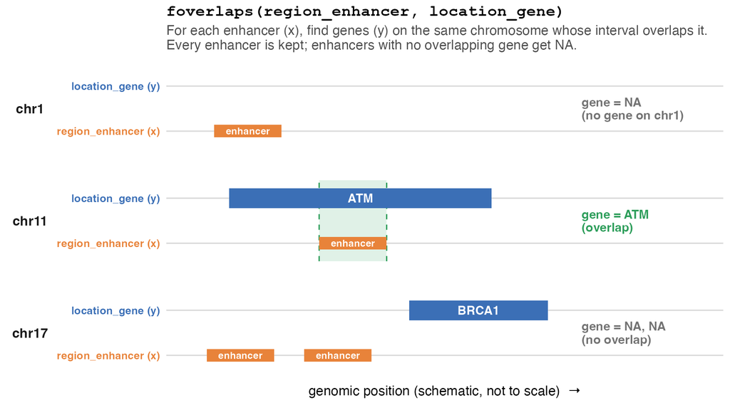

```r
# First we set the values
setkey(region_enhancer, chr, start, end)
setkey(location_gene, chr, start, end)
### Then we use foverlaps
foverlaps(region_enhancer, location_gene)
```

| chr | gene | start | end | i.start | i.end |
| --- | --- | --- | --- | --- | --- |
| chr1 | NA | NA | NA | 100 | 900 |
| chr11 | ATM | 108230374 | 108376593 | 108300000 | 108301500 |
| chr17 | NA | NA | NA | 9200 | 9900 |
| chr17 | NA | NA | NA | 4390100 | 4391000 |

**Tip**

**What are `start`, `end`, `i.start` and `i.end`?**

Both tables have columns called `start` and `end`, and the result needs both sets of coordinates, so `foverlaps(x, y)` renames one of them:

- **`start`, `end`** come from **y** (the second table) and keep their names
- **`i.start`, `i.end`** come from **x** (the first table); every column of x whose name also exists in y gets the prefix `i.`

```
  chr   gene     start       end   i.start     i.end
chr11    ATM 108230374 108376593 108300000 108301500
               └── gene (y) ──┘   └ enhancer (x) ┘
```

Why “i”? It comes from data.table’s join syntax `X[i]`, where `i` is the table being joined in. `foverlaps(x, y)` works like `y[x]`, so x plays the role of `i`. `chr` has no prefix because it is a join column and is the same in both tables.

#### Does the order of the tables matter?

The overlapping pair is the same both ways (the chr11 enhancer and ATM). What changes is **which table every row is kept from**. In `foverlaps(x, y)`, **x is the “main” table** (like a left join on x):

|  | `foverlaps(region_enhancer, location_gene)` | `foverlaps(location_gene, region_enhancer)` |
| --- | --- | --- |
| Question asked | “For each **enhancer**, which gene overlaps it?” | “For each **gene**, which enhancer overlaps it?” |
| Rows | 4, one per enhancer | 2, one per gene |
| Unmatched rows | 3 enhancers with `gene = NA` | BRCA1 with enhancer `start/end = NA` |
| `start`, `end` | gene coordinates | enhancer coordinates |
| `i.start`, `i.end` | enhancer coordinates | gene coordinates |

The `i.` columns always come from the **first** argument (x).

```r
foverlaps(region_enhancer, location_gene)
```

| chr | gene | start | end | i.start | i.end |
| --- | --- | --- | --- | --- | --- |
| chr1 | NA | NA | NA | 100 | 900 |
| chr11 | ATM | 108230374 | 108376593 | 108300000 | 108301500 |
| chr17 | NA | NA | NA | 9200 | 9900 |
| chr17 | NA | NA | NA | 4390100 | 4391000 |

```r
foverlaps(location_gene, region_enhancer)
```

| chr | start | end | gene | i.start | i.end |
| --- | --- | --- | --- | --- | --- |
| chr11 | 108300000 | 108301500 | ATM | 108230374 | 108376593 |
| chr17 | NA | NA | BRCA1 | 43902857 | 43983996 |

**Tip**

Put first the table you want one row for. Use `nomatch = NULL` to keep only the rows that overlap.

**Note**

**Important arguments of `foverlaps(x, y, ...)`**

- **`type`** - what counts as an overlap between an interval of x and an interval of y:
  - `"any"` (default) - the intervals share at least one position
  - `"within"` - x lies fully inside y (so here the order of x and y matters)
  - `"start"` - x and y start at the same position
  - `"end"` - x and y end at the same position
  - `"equal"` - x and y have exactly the same start and end
- **`nomatch`** - `NA` (default) keeps rows of x without an overlap and fills them with `NA`; `NULL` drops them
- **`mult`** - when one row of x overlaps several rows of y: `"all"` (default) returns all of them, `"first"` or `"last"` only one
- **`which`** - if `TRUE`, returns only the row numbers of the overlapping rows (`xid`, `yid`) instead of the joined table
- **`by.x`**, **`by.y`** - the columns to overlap on; by default the keys of the tables. The last two must be the start and end of the interval

```r
# Only enhancers that overlap a gene
foverlaps(region_enhancer, location_gene, nomatch = NULL)
```

| chr | gene | start | end | i.start | i.end |
| --- | --- | --- | --- | --- | --- |
| chr11 | ATM | 108230374 | 108376593 | 108300000 | 108301500 |

```r
# Enhancers that lie fully inside a gene
foverlaps(region_enhancer, location_gene, type = "within", nomatch = NULL)
```

| chr | gene | start | end | i.start | i.end |
| --- | --- | --- | --- | --- | --- |
| chr11 | ATM | 108230374 | 108376593 | 108300000 | 108301500 |

```r
# Enhancers that start at the same position as a gene -> none here
foverlaps(region_enhancer, location_gene, type = "start", nomatch = NULL)
```

| chr | gene | start | end | i.start | i.end |
| --- | --- | --- | --- | --- | --- |

```r
# Row numbers only: enhancer 2 overlaps gene 1
foverlaps(region_enhancer, location_gene, which = TRUE)
```

| xid | yid |
| --- | --- |
| 1 | NA |
| 2 | 1 |
| 3 | NA |
| 4 | NA |